# Chap7.2

Mijeong Kim

```r
library(tsibble)
library(tsibbledata)
library(tibble)
library(dplyr)
library(knitr)
library(ggplot2)
library(fpp3)
library(fpp2)
library(seasonal)
library(feasts)
```

## 7.2 최소제곱 추정 (Least Squares Estimation)

- 실제 데이터 분석에서는 계수 $\beta_0, \beta_1, \dots, \beta_k$의 값을 모르기 때문에 데이터를 통해 추정한다.
- **최소제곱 원리(Least Squares Principle)** 는 오차 제곱합을 최소화하는 방식으로 계수를 선택한다.

$$\sum_{t=1}^{T} \varepsilon_t^2 = \sum_{t=1}^{T} \left(y_t - \beta_0 -
\beta_1 x_{1,t} - \cdots - \beta_k x_{k,t} \right)^2$$

- 이렇게 추정된 계수를 **최소제곱 추정값**이라 하며, 모델을 데이터에 적합(fit)시킨다고 표현한다.
- 추정된 계수는 $\hat{\beta}_0, \hat{\beta}_1, \dots, \hat{\beta}_k$ 로 나타낸다.
- 관련된 수식은 7.9절에서 소개한다.

## TSLM() 함수 소개

- `TSLM()`은 시계열 데이터를 위한 선형 회귀 모델을 적합시키는 함수다.
- 일반적인 `lm()` 함수와 유사하지만, 시계열 처리에 특화된 기능을 포함한다.

### 미국 소비 지출 예제 (US Consumption Expenditure)

미국 소비 지출에 대한 다중 선형 회귀 모델은 다음과 같다:

$$y_t = \beta_0 + \beta_1 x_{1,t} + \beta_2 x_{2,t} + \beta_3 x_{3,t} +
\beta_4 x_{4,t} + \varepsilon_t$$

여기서:

- $y_t$: 실질 개인 소비 지출의 백분율 변화
- $x_{1,t}$: 실질 개인 가처분 소득의 백분율 변화
- $x_{2,t}$: 산업 생산의 백분율 변화
- $x_{3,t}$: 개인 저축의 백분율 변화
- $x_{4,t}$: 실업률의 변화

#### 회귀 분석 결과 해석

회귀 결과에서 **계수(Coefficients)**의 첫 번째 열은 각 $\beta$ 계수의 추정값을 나타낸다.  
두 번째 열은 해당 계수의 **표준 오차(Standard Error)**를 나타내며, 이는 유사한 데이터셋에서 반복적으로 계수를 추정했을 때 얻어지는 표준 편차다.

표준 오차는 추정된 계수의 **불확실성 정도를 측정하는 지표**가 된다.

```r
fit_consMR <- us_change |>
  model(tslm = TSLM(Consumption ~ Income + Production +
                                    Unemployment + Savings))
report(fit_consMR)
```

```
## Series: Consumption
## Model: TSLM
##
## Residuals:
##      Min       1Q   Median       3Q      Max
## -0.90555 -0.15821 -0.03608  0.13618  1.15471
##
## Coefficients:
##               Estimate Std. Error t value Pr(>|t|)
## (Intercept)   0.253105   0.034470   7.343 5.71e-12 ***
## Income        0.740583   0.040115  18.461  < 2e-16 ***
## Production    0.047173   0.023142   2.038   0.0429 *
## Unemployment -0.174685   0.095511  -1.829   0.0689 .
## Savings      -0.052890   0.002924 -18.088  < 2e-16 ***
## ---
## Signif. codes:  0 '***' 0.001 '**' 0.01 '*' 0.05 '.' 0.1 ' ' 1
##
## Residual standard error: 0.3102 on 193 degrees of freedom
## Multiple R-squared: 0.7683,  Adjusted R-squared: 0.7635
## F-statistic:   160 on 4 and 193 DF, p-value: < 2.22e-16
```

#### 회귀 결과에서 t값과 p값의 의미

이 값들은 각 설명 변수의 영향을 분석할 때는 유용하지만, **예측 자체에는 큰 도움이 되지 않는다.**

### 적합값(Fitted Values)

- 회귀 방정식에 추정된 계수를 대입하고 오차항을 0으로 설정하면 \( y \)의 예측값을 얻을 수 있다.

$$\hat{y}_t = \hat{\beta}_0 + \hat{\beta}_1 x_{1,t} + \hat{\beta}_2
x_{2,t} + \cdots + \hat{\beta}_k x_{k,t}
\tag{7.2}$$

### 적합값 시각화

- 그림 7.6의 시계열 플롯에서는 적합값이 실제 소비 지출 변화율과 상당히 유사한 추세를 보인다.
- 그림 7.7의 산점도는 실제값과 적합값 사이에 강한 양의 상관관계를 나타내며, 적합도가 높음을 확인시켜준다.

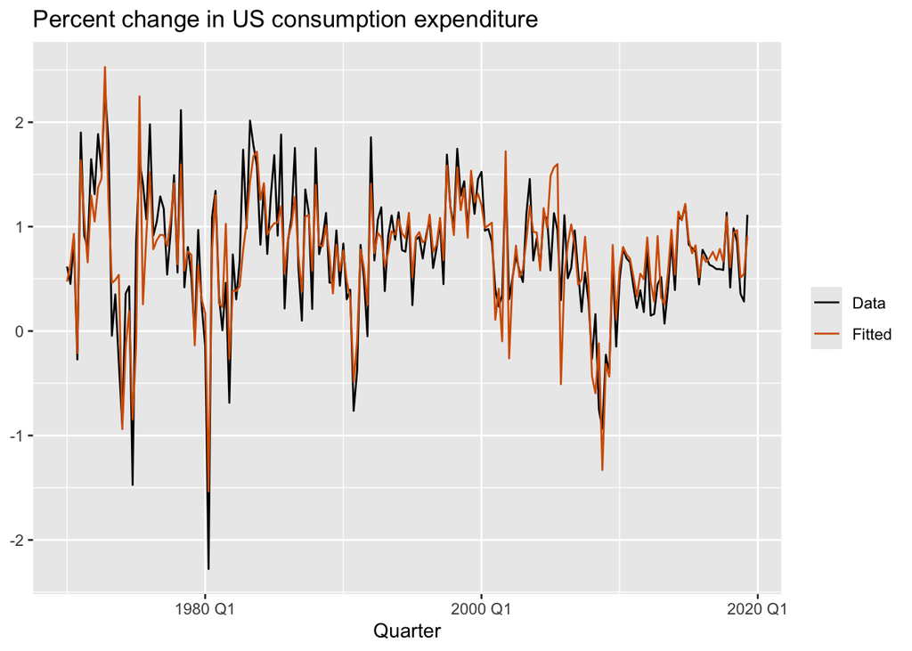

```r
augment(fit_consMR) |>
  ggplot(aes(x = Quarter)) +
  geom_line(aes(y = Consumption, colour = "Data")) +
  geom_line(aes(y = .fitted, colour = "Fitted")) +
  labs(y = NULL,
    title = "Percent change in US consumption expenditure"
  ) +
  scale_colour_manual(values=c(Data="black",Fitted="#D55E00")) +
  guides(colour = guide_legend(title = NULL))
```

Figure 7.6: Time plot of actual US consumption expenditure and predicted US consumption expenditure.

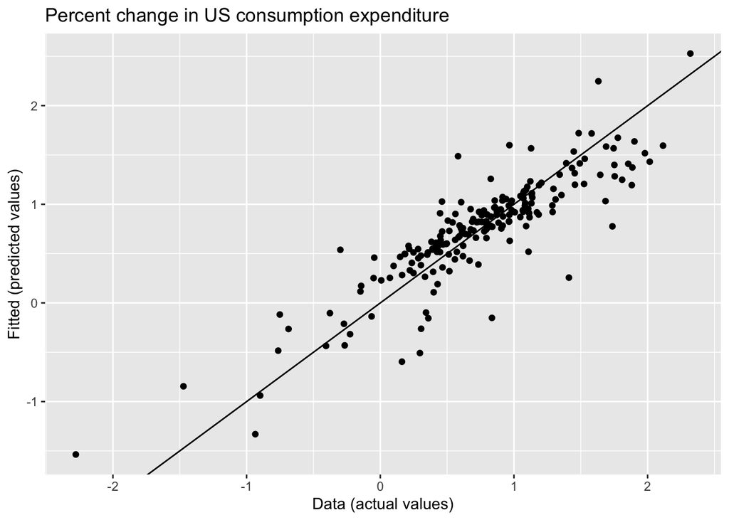

```r
augment(fit_consMR) |>
  ggplot(aes(x = Consumption, y = .fitted)) +
  geom_point() +
  labs(
    y = "Fitted (predicted values)",
    x = "Data (actual values)",
    title = "Percent change in US consumption expenditure"
  ) +
  geom_abline(intercept = 0, slope = 1)
```

Figure 7.7: Actual US consumption expenditure plotted against predicted US consumption expenditure.

### 적합도 평가 (Goodness-of-fit)

결정계수 $R^2$ - 선형 회귀 모델의 적합도를 요약하는 대표적인 지표는 **결정계수 $R^2$** 이다. - 이는 실제값 $y$와 예측값 $\hat{y}$ 사이의 상관계수 제곱으로 계산하거나, 아래 수식으로 계산한다:

$$R^2 = \frac{\sum (\hat{y}_t - \bar{y})^2}{\sum (y_t - \bar{y})^2}$$

- $R^2$는 회귀 모델이 종속 변수의 변동성을 얼마나 설명하는지를 나타내며, 0과 1 사이의 값을 가진다.
- 단순 회귀의 경우, $R^2$는 $y$와 $x$ 사이의 상관계수 제곱과 같다 (절편이 포함된 경우).
- **$R^2$가 1에 가까울수록 예측값이 실제값에 가깝고, 0에 가까울수록 예측력이 낮다.**
- 하지만, 예측 변수 추가 시 $R^2$는 절대 감소하지 않기 때문에 과적합(overfitting)의 원인이 될 수 있다.
- **훈련 데이터에서의 $R^2$보다는 테스트 데이터에서의 예측 성능 검증이 더 중요하다.**

### 예시: 미국 소비 지출

- 실제 소비 지출 값과 적합값의 상관계수는 $r = 0.877$, 따라서 $R^2 = 0.768$이다.
- 모델은 소비 지출 변동성의 **76.8%** 를 설명하며, 이는 7.1절에서 단일 예측 변수만 사용해 얻은 $R^2 = 0.15$ 보다 훨씬 높다.

## 회귀의 표준 오차 (Residual Standard Error)

- **잔차의 표준 편차**, 또는 **회귀의 표준 오차(Residual Standard Error)** 는 모델의 평균 오차 크기를 나타낸다.
- 아래 수식으로 계산된다:

$$\hat{\sigma}_e = \sqrt{\frac{1}{T - k - 1} \sum_{t=1}^{T} e_t^2}
\tag{7.3}$$

- 여기서 $k$는 예측 변수의 수이며, 분모는 추정된 파라미터 수를 반영해 $T - k - 1$로 나눈다.
- 이 오차는 예측값이 실제값과 얼마나 차이나는지를 수치적으로 보여주며, $y$의 평균 또는 표준편차와 비교해 모델의 정확도를 파악할 수 있다.
- 예측 구간(prediction interval)을 생성할 때도 이 표준 오차를 사용하며, 이는 7.6절에서 다룬다.